# thompson-ryan-ADA-homework-4.git

KRT

5/4/2020

## cv_data data frame

[output not shown]

## Challenge 1

```r
### Challenge 1
cv_summary(d = cv_data)
```

```
## $totals
## # A tibble: 6 x 8
##   country variable          cases population      area density   rate on
##   <chr>   <chr>             <dbl>      <dbl>     <dbl>   <dbl>  <dbl> <date>
## 1 World   confirmed       4100108 7523799801    1.27e8    59.4 545.   2020-05-10
## 2 World   daily_confirmed   99113 7523799801    1.27e8    59.4  13.2  2020-05-10
## 3 World   daily_deaths       8856 7523799801    1.27e8    59.4   1.18 2020-05-10
## 4 World   daily_recovered   65439 7523799801    1.27e8    59.4   8.70 2020-05-10
## 5 World   deaths           282666 7523799801    1.27e8    59.4  37.6  2020-05-10
## 6 World   recovered       1407676 7523799801    1.27e8    59.4 187.   2020-05-10
##
## $cum_cases_plot
```

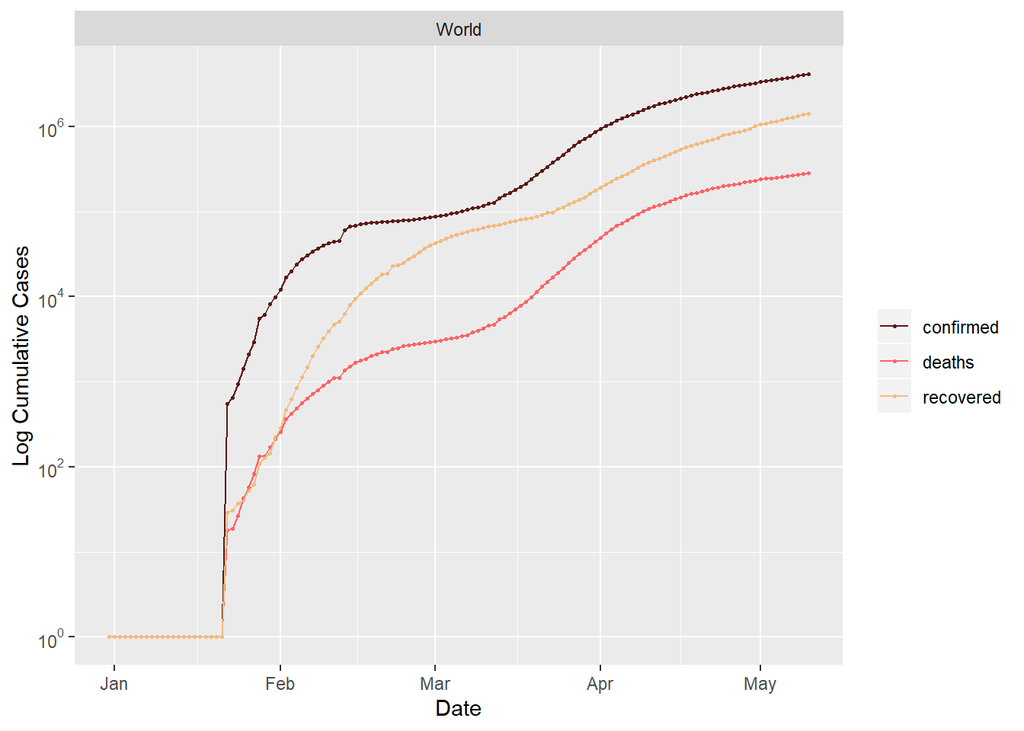

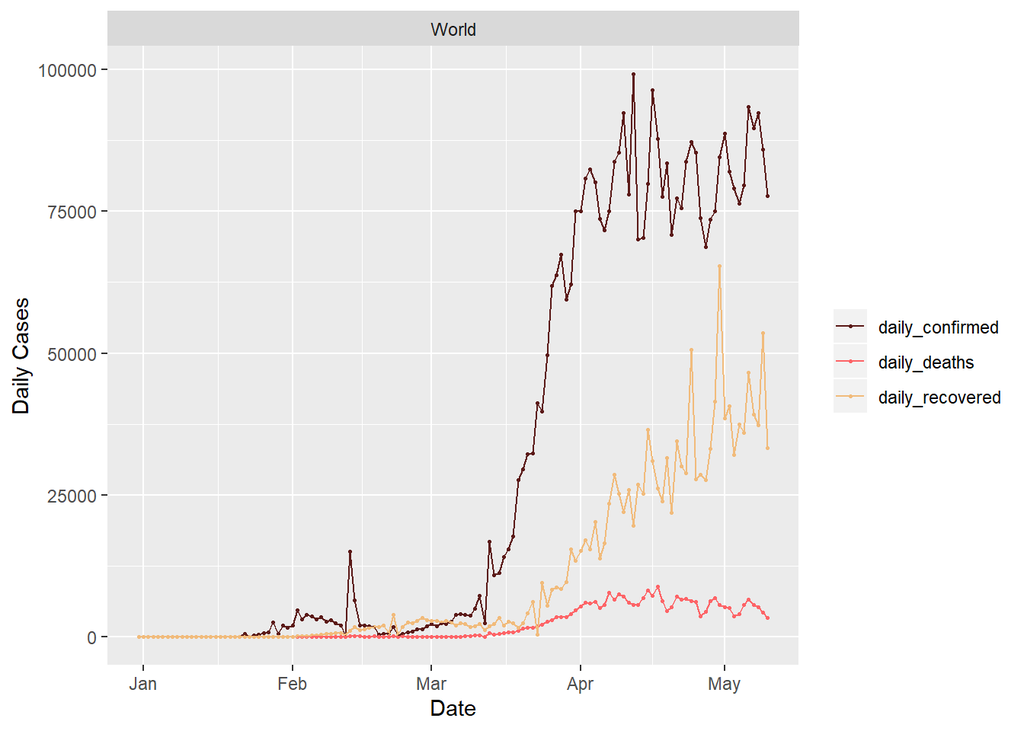

## Challenge 2

```r
### Challenge 2
## by country
cv_summary(d = cv_data, country_list = c("United States", "United Kingdom",
                                         "Canada", "France", "Germany",
                                         "Italy", "Japan", "China",
                                         "Russia", "Iran"))
```

```
## $totals
## # A tibble: 60 x 13
##    country variable cases population   area density    rate gdp_capita income
##    <chr>   <chr>    <dbl>      <dbl>  <dbl>   <dbl>   <dbl>      <dbl> <chr>
##  1 Canada  confirm~ 70091   37057765 9.09e6    4.08 1.89e+3     51392. High ~
##  2 Canada  daily_c~  2778   37057765 9.09e6    4.08 7.50e+1     51392. High ~
##  3 Canada  daily_d~   251   37057765 9.09e6    4.08 6.77e+0     51392. High ~
##  4 Canada  daily_r~  1385   37057765 9.09e6    4.08 3.74e+1     51392. High ~
##  5 Canada  deaths    4991   37057765 9.09e6    4.08 1.35e+2     51392. High ~
##  6 Canada  recover~ 32109   37057765 9.09e6    4.08 8.66e+2     51392. High ~
##  7 China   confirm~ 84010 1392730000 9.39e6  148.   6.03e+1      7753. Upper~
##  8 China   daily_c~ 15136 1392730000 9.39e6  148.   1.09e+1      7753. Upper~
##  9 China   daily_d~  1290 1392730000 9.39e6  148.   9.26e-1      7753. Upper~
## 10 China   daily_r~  3995 1392730000 9.39e6  148.   2.87e+0      7753. Upper~
## # ... with 50 more rows, and 4 more variables: life_expectancy <dbl>,
## #   max_sd <dbl>, max_mr <dbl>, on <date>
##
## $cum_cases_plot
```

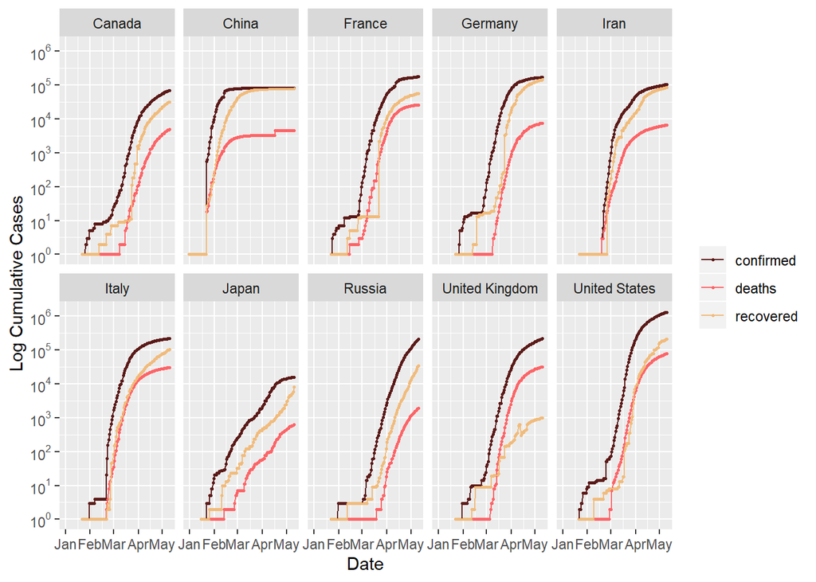

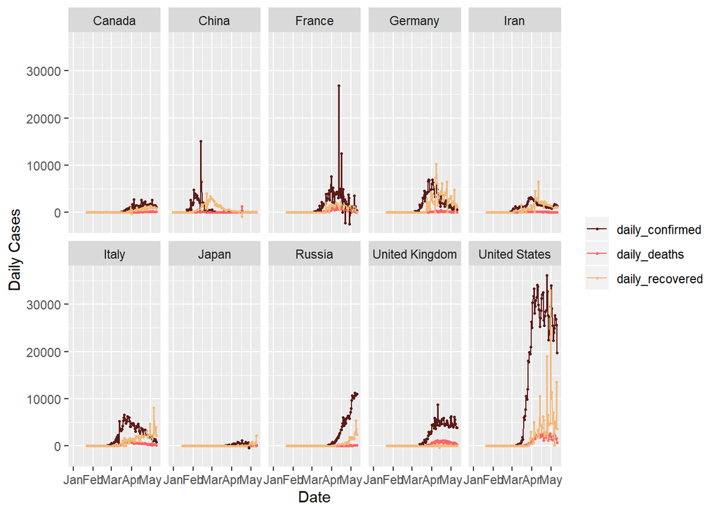

```r
## by variable
cv_summary(d = cv_data, country_list = c("United States", "United Kingdom",
                                         "Canada", "France", "Germany",
                                         "Italy", "Japan", "China",
                                         "Russia", "Iran"),
           facet = "variable")
```

```
## $totals
## # A tibble: 60 x 13
##    country variable cases population   area density    rate gdp_capita income
##    <chr>   <chr>    <dbl>      <dbl>  <dbl>   <dbl>   <dbl>      <dbl> <chr>
##  1 Canada  confirm~ 70091   37057765 9.09e6    4.08 1.89e+3     51392. High ~
##  2 Canada  daily_c~  2778   37057765 9.09e6    4.08 7.50e+1     51392. High ~
##  3 Canada  daily_d~   251   37057765 9.09e6    4.08 6.77e+0     51392. High ~
##  4 Canada  daily_r~  1385   37057765 9.09e6    4.08 3.74e+1     51392. High ~
##  5 Canada  deaths    4991   37057765 9.09e6    4.08 1.35e+2     51392. High ~
##  6 Canada  recover~ 32109   37057765 9.09e6    4.08 8.66e+2     51392. High ~
##  7 China   confirm~ 84010 1392730000 9.39e6  148.   6.03e+1      7753. Upper~
##  8 China   daily_c~ 15136 1392730000 9.39e6  148.   1.09e+1      7753. Upper~
##  9 China   daily_d~  1290 1392730000 9.39e6  148.   9.26e-1      7753. Upper~
## 10 China   daily_r~  3995 1392730000 9.39e6  148.   2.87e+0      7753. Upper~
## # ... with 50 more rows, and 4 more variables: life_expectancy <dbl>,
## #   max_sd <dbl>, max_mr <dbl>, on <date>
##
## $cum_cases_plot
```

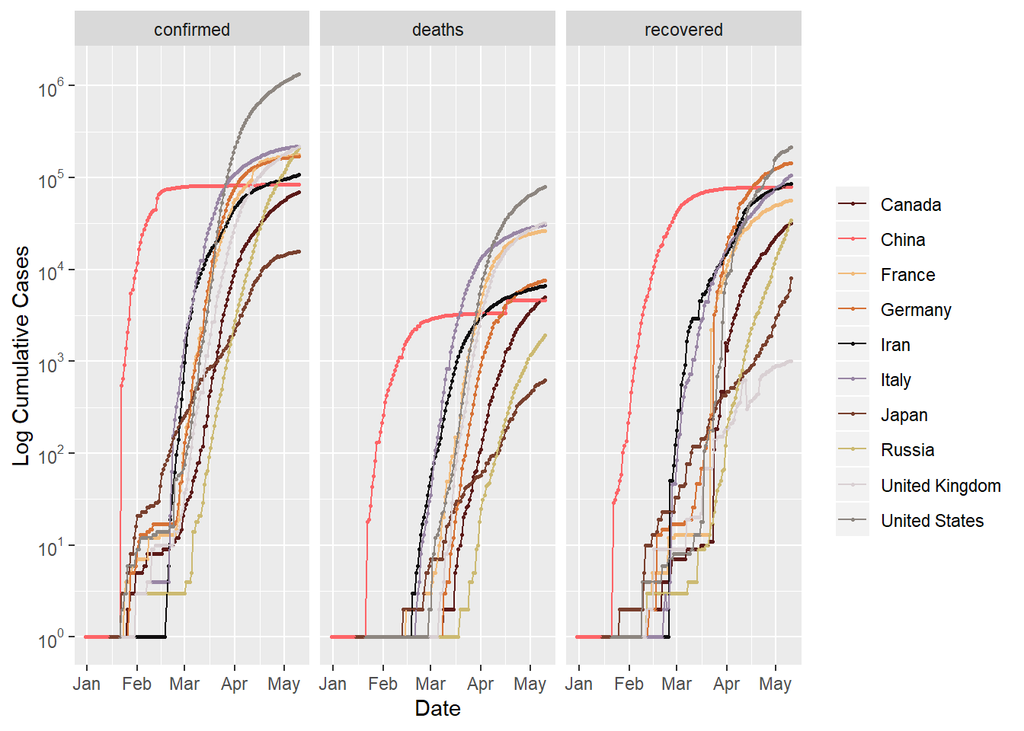

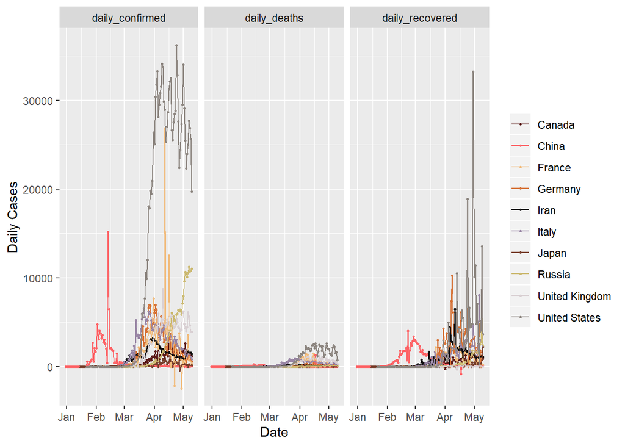

## Challenge 3

```r
### Challenge 3
d <- cv_summary(d = cv_data, country_list = "All", plot = FALSE)
d <- d[[1]] %>% filter(population > 1000000)
length(unique(d$country))
```

```
## [1] 154
```

There are 154 countries included in this tibble.

## Challenge 4

```r
### Challenge 4
overall <- d %>% filter(variable == "confirmed") %>% arrange(desc(cases))
daily <- d %>% filter(variable == "daily_confirmed") %>% arrange(desc(cases))

head(overall, 10)
```

```
## # A tibble: 10 x 13
##    country variable  cases population   area density  rate gdp_capita income
##    <chr>   <chr>     <dbl>      <dbl>  <dbl>   <dbl> <dbl>      <dbl> <chr>
##  1 United~ confirm~ 1.33e6  326687501 9.15e6   35.8  4069.     54579. High ~
##  2 Spain   confirm~ 2.24e5   46796540 5.00e5   93.5  4794.     32950. High ~
##  3 United~ confirm~ 2.20e5   66460344 2.42e5  275.   3317.     43325. High ~
##  4 Italy   confirm~ 2.19e5   60421760 2.94e5  205.   3626.     35432. High ~
##  5 Russia  confirm~ 2.10e5  144478050 1.64e7    8.82 1451.     11729. Upper~
##  6 France  confirm~ 1.77e5   66977107 5.48e5  122.   2644.     43664. High ~
##  7 Germany confirm~ 1.72e5   82905782 3.49e5  237.   2073.     47478. High ~
##  8 Brazil  confirm~ 1.63e5  209469333 8.36e6   25.1   777.     11026. Upper~
##  9 Turkey  confirm~ 1.39e5   82319724 7.70e5  107.   1684.     15069. Upper~
## 10 Iran    confirm~ 1.08e5   81800269 1.63e6   50.2  1315.      6952. Upper~
## # ... with 4 more variables: life_expectancy <dbl>, max_sd <dbl>, max_mr <dbl>,
## #   on <date>
```

```r
head(daily, 10)
```

```
## # A tibble: 10 x 13
##    country variable cases population   area density  rate gdp_capita income
##    <chr>   <chr>    <dbl>      <dbl>  <dbl>   <dbl> <dbl>      <dbl> <chr>
##  1 United~ daily_c~ 36188  326687501 9.15e6   35.8  111.      54579. High ~
##  2 France  daily_c~ 26849   66977107 5.48e5  122.   401.      43664. High ~
##  3 China   daily_c~ 15136 1392730000 9.39e6  148.    10.9      7753. Upper~
##  4 Ecuador daily_c~ 11536   17084357 2.48e5   68.8  675.       5185. Upper~
##  5 Russia  daily_c~ 11231  144478050 1.64e7    8.82  77.7     11729. Upper~
##  6 Brazil  daily_c~ 11156  209469333 8.36e6   25.1   53.3     11026. Upper~
##  7 Spain   daily_c~  9630   46796540 5.00e5   93.5  206.      32950. High ~
##  8 United~ daily_c~  8733   66460344 2.42e5  275.   131.      43325. High ~
##  9 Germany daily_c~  6933   82905782 3.49e5  237.    83.6     47478. High ~
## 10 Italy   daily_c~  6557   60421760 2.94e5  205.   109.      35432. High ~
## # ... with 4 more variables: life_expectancy <dbl>, max_sd <dbl>, max_mr <dbl>,
## #   on <date>
```

## Challenge 5

```r
### Challenge 5

overall <- na.omit(overall)

## Not transformed
full <- lm(rate ~ density + population + gdp_capita + income, data = overall)
full
```

```
##
## Call:
## lm(formula = rate ~ density + population + gdp_capita + income,
##     data = overall)
##
## Coefficients:
##               (Intercept)                    density
##                 2.838e+02                  2.275e-01
##                population                 gdp_capita
##                -1.027e-07                  4.101e-02
##          incomeLow income  incomeLower middle income
##                -2.939e+02                 -2.819e+02
## incomeUpper middle income
##                -9.665e+01
```

```r
summary(full)
```

```
##
## Call:
## lm(formula = rate ~ density + population + gdp_capita + income,
##     data = overall)
##
## Residuals:
##     Min      1Q  Median      3Q     Max
## -2537.2  -334.6   -64.4    40.5  5163.2
##
## Coefficients:
##                             Estimate Std. Error t value Pr(>|t|)
## (Intercept)                2.838e+02  2.795e+02   1.015   0.3118
## density                    2.275e-01  1.080e-01   2.107   0.0369 *
## population                -1.027e-07  4.458e-07  -0.230   0.8181
## gdp_capita                 4.101e-02  6.645e-03   6.172 6.65e-09 ***
## incomeLow income          -2.939e+02  3.229e+02  -0.910   0.3643
## incomeLower middle income -2.819e+02  3.049e+02  -0.925   0.3568
## incomeUpper middle income -9.665e+01  2.729e+02  -0.354   0.7237
## ---
## Signif. codes:  0 '***' 0.001 '**' 0.01 '*' 0.05 '.' 0.1 ' ' 1
##
## Residual standard error: 872.6 on 142 degrees of freedom
## Multiple R-squared:  0.533,  Adjusted R-squared:  0.5133
## F-statistic: 27.02 on 6 and 142 DF,  p-value: < 2.2e-16
```

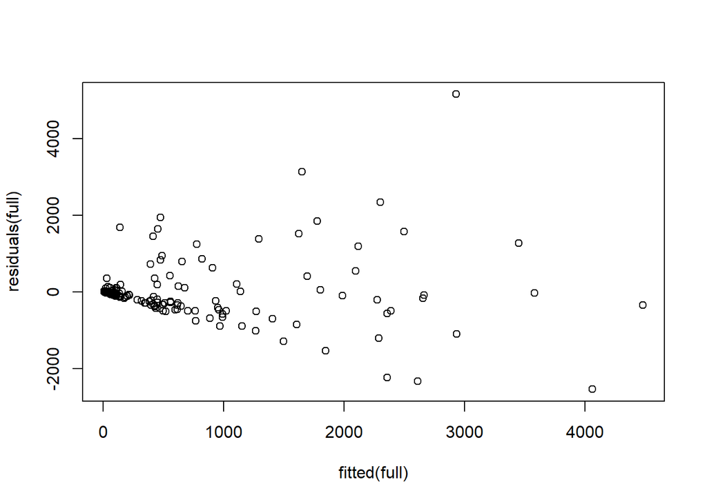

```r
plot(fitted(full), residuals(full))
```

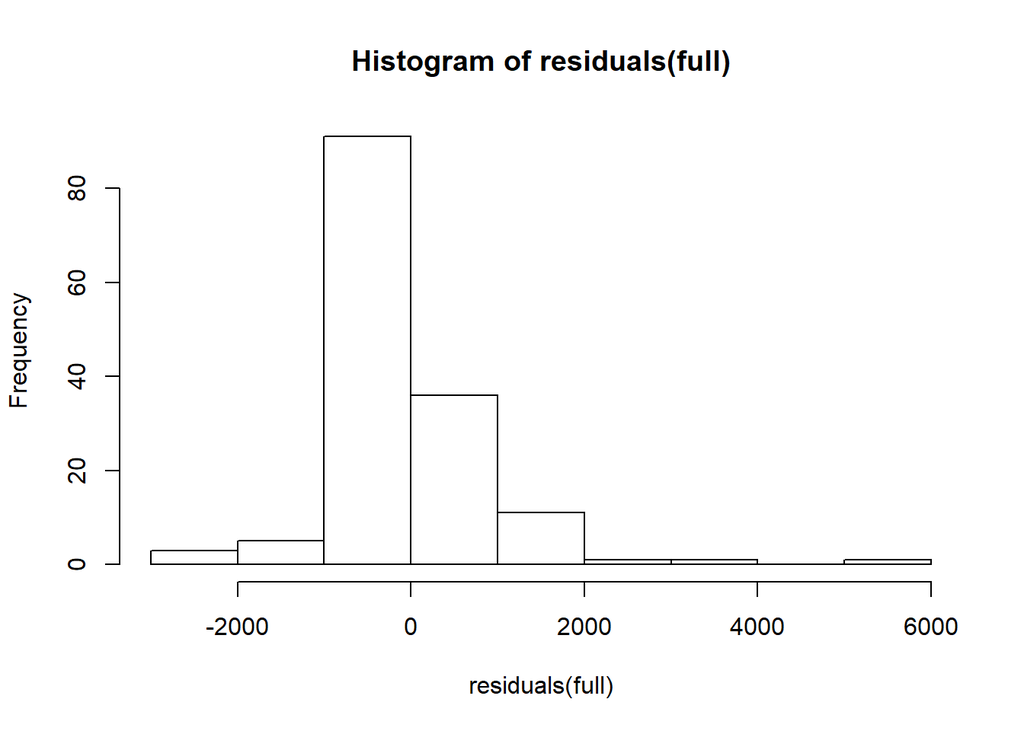

```r
hist(residuals(full))
```

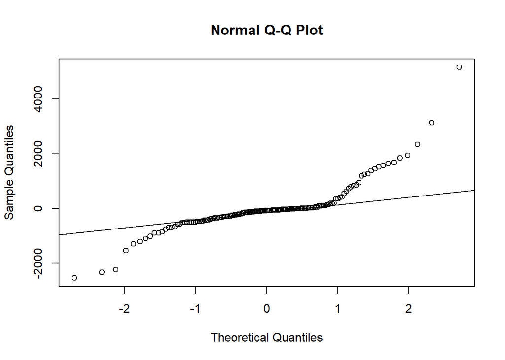

```r
qqnorm(residuals(full))
qqline(residuals(full))
```

```r
## rate log transformed
full <- lm(log(rate) ~ density + population + gdp_capita + income, data = overall)
full
```

```
##
## Call:
## lm(formula = log(rate) ~ density + population + gdp_capita +
##     income, data = overall)
##
## Coefficients:
##               (Intercept)                    density
##                 5.965e+00                  1.392e-04
##                population                 gdp_capita
##                -1.769e-10                  2.813e-05
##          incomeLow income  incomeLower middle income
##                -3.225e+00                 -2.470e+00
## incomeUpper middle income
##                -7.934e-01
```

```r
summary(full)
```

```
##
## Call:
## lm(formula = log(rate) ~ density + population + gdp_capita +
##     income, data = overall)
##
## Residuals:
##     Min      1Q  Median      3Q     Max
## -3.6363 -0.8078  0.1754  0.9869  3.9211
##
## Coefficients:
##                             Estimate Std. Error t value Pr(>|t|)
## (Intercept)                5.965e+00  4.681e-01  12.743  < 2e-16 ***
## density                    1.392e-04  1.808e-04   0.770   0.4427
## population                -1.769e-10  7.465e-10  -0.237   0.8130
## gdp_capita                 2.813e-05  1.113e-05   2.528   0.0126 *
## incomeLow income          -3.225e+00  5.407e-01  -5.965 1.85e-08 ***
## incomeLower middle income -2.470e+00  5.105e-01  -4.839 3.36e-06 ***
## incomeUpper middle income -7.934e-01  4.569e-01  -1.737   0.0846 .
## ---
## Signif. codes:  0 '***' 0.001 '**' 0.01 '*' 0.05 '.' 0.1 ' ' 1
##
## Residual standard error: 1.461 on 142 degrees of freedom
## Multiple R-squared:  0.5796, Adjusted R-squared:  0.5618
## F-statistic: 32.63 on 6 and 142 DF,  p-value: < 2.2e-16
```

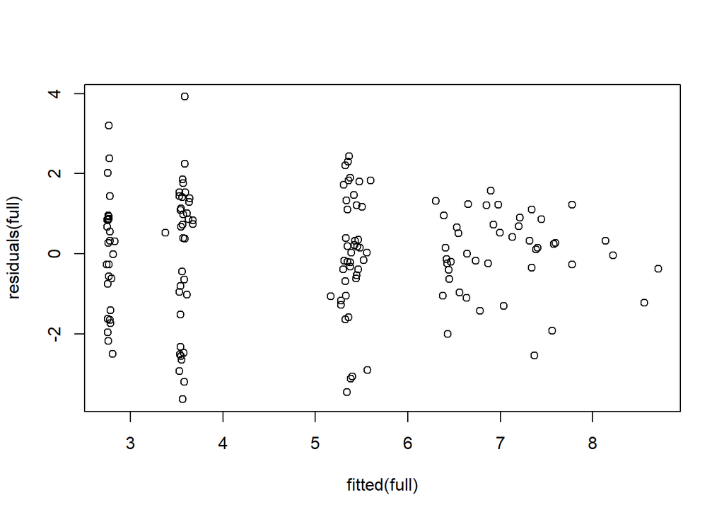

```r
plot(fitted(full), residuals(full))
```

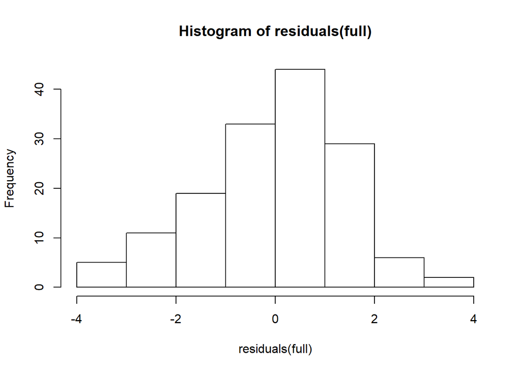

```r
hist(residuals(full))
```

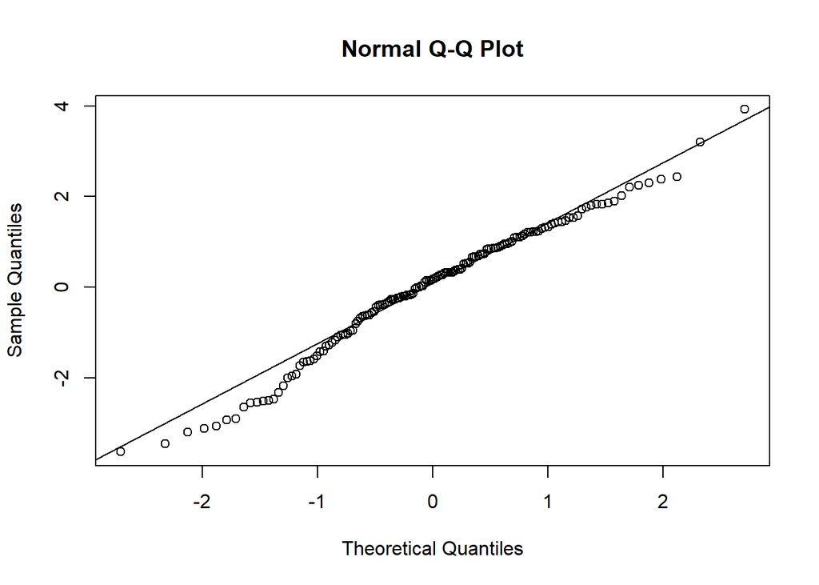

```r
qqnorm(residuals(full))
qqline(residuals(full))
```

```r
## density, population, and gdp_captia also transformed
full <- full <- lm(log(rate) ~ log(density) + log(population) + log(gdp_capita) + income, data = overall)
full
```

```
##
## Call:
## lm(formula = log(rate) ~ log(density) + log(population) + log(gdp_capita) +
##     income, data = overall)
##
## Coefficients:
##               (Intercept)               log(density)
##                  -3.55854                    0.22345
##           log(population)            log(gdp_capita)
##                  -0.05094                    1.00409
##          incomeLow income  incomeLower middle income
##                  -0.25658                   -0.69847
## incomeUpper middle income
##                  -0.01889
```

```r
summary(full)
```

```
##
## Call:
## lm(formula = log(rate) ~ log(density) + log(population) + log(gdp_capita) +
##     income, data = overall)
##
## Residuals:
##     Min      1Q  Median      3Q     Max
## -3.4827 -0.8328  0.0527  0.9589  3.5207
##
## Coefficients:
##                           Estimate Std. Error t value Pr(>|t|)
## (Intercept)               -3.55854    2.95087  -1.206 0.229850
## log(density)               0.22345    0.08930   2.502 0.013480 *
## log(population)           -0.05094    0.08427  -0.605 0.546465
## log(gdp_capita)            1.00409    0.26668   3.765 0.000243 ***
## incomeLow income          -0.25658    1.11256  -0.231 0.817941
## incomeLower middle income -0.69847    0.79670  -0.877 0.382125
## incomeUpper middle income -0.01889    0.51275  -0.037 0.970661
## ---
## Signif. codes:  0 '***' 0.001 '**' 0.01 '*' 0.05 '.' 0.1 ' ' 1
##
## Residual standard error: 1.406 on 142 degrees of freedom
## Multiple R-squared:  0.6109, Adjusted R-squared:  0.5944
## F-statistic: 37.15 on 6 and 142 DF,  p-value: < 2.2e-16
```

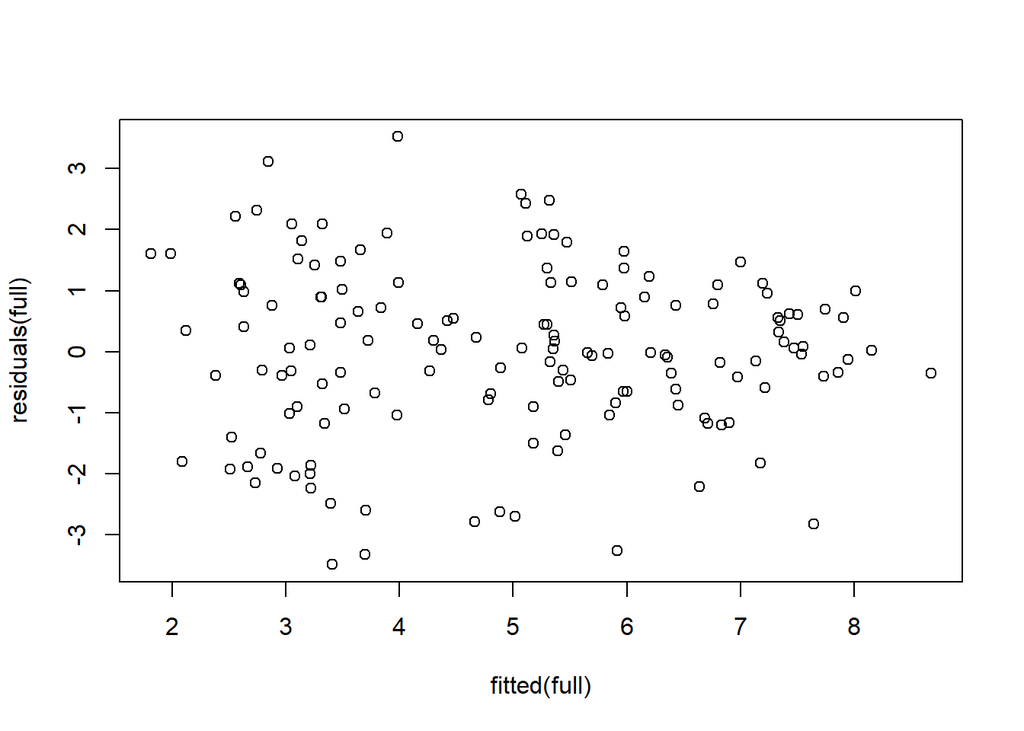

```r
plot(fitted(full), residuals(full))
```

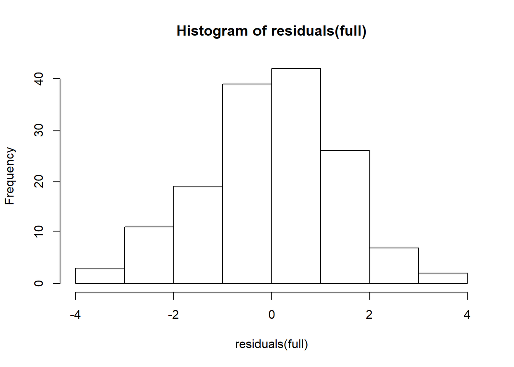

```r
hist(residuals(full))
```

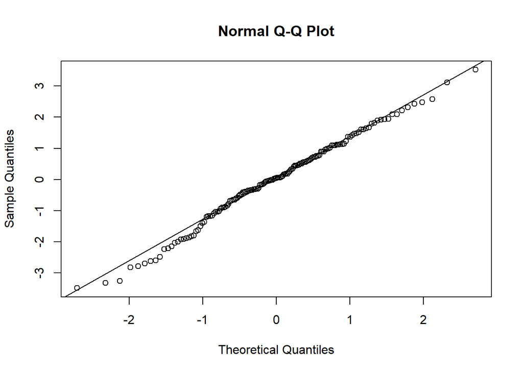

```r
qqnorm(residuals(full))
qqline(residuals(full))
```

Based off the log transformed full model, log(density) and log(gdp_capita) have slopes that are significantly different from 0.

## Challenge 6

```r
### Challenge 6

m <- lm(data = overall, log(rate) ~ log(density) + log(population) + log(gdp_capita) + income)
s <- stepAIC(m, scope = . ~ ., direction = "both")
```

```
## Start:  AIC=108.3
## log(rate) ~ log(density) + log(population) + log(gdp_capita) +
##     income
##
##                   Df Sum of Sq    RSS    AIC
## - income           3    7.6833 288.25 106.33
## - log(population)  1    0.7221 281.29 106.68
## <none>                         280.57 108.30
## - log(density)     1   12.3701 292.94 112.73
## - log(gdp_capita)  1   28.0117 308.58 120.48
##
## Step:  AIC=106.33
## log(rate) ~ log(density) + log(population) + log(gdp_capita)
##
##                   Df Sum of Sq    RSS    AIC
## - log(population)  1      1.52 289.77 105.11
## <none>                         288.26 106.33
## + income           3      7.68 280.57 108.30
## - log(density)     1     12.21 300.46 110.51
## - log(gdp_capita)  1    402.91 691.16 234.63
##
## Step:  AIC=105.11
## log(rate) ~ log(density) + log(gdp_capita)
##
##                   Df Sum of Sq    RSS    AIC
## <none>                         289.77 105.11
## + log(population)  1      1.52 288.26 106.33
## + income           3      8.48 281.29 106.68
## - log(density)     1     11.36 301.13 108.84
## - log(gdp_capita)  1    412.87 702.64 235.09
```

```r
r.squaredGLMM(m)
```

```
##            R2m       R2c
## [1,] 0.6009867 0.6009867
```

```r
r.squaredGLMM(s)
```

```
##            R2m       R2c
## [1,] 0.5948336 0.5948336
```

```r
daily <- na.omit(daily)

m1 <- lm(data = daily, log(rate) ~ log(density) + log(population) + log(gdp_capita) + income)
s1 <- stepAIC(m1, scope = . ~ ., direction = "both")
```

```
## Start:  AIC=72.66
## log(rate) ~ log(density) + log(population) + log(gdp_capita) +
##     income
##
##                   Df Sum of Sq    RSS    AIC
## - income           3    5.4297 226.31 70.274
## <none>                         220.88 72.656
## - log(density)     1    5.7603 226.64 74.492
## - log(population)  1   10.3049 231.18 77.450
## - log(gdp_capita)  1   22.2865 243.16 84.979
##
## Step:  AIC=70.27
## log(rate) ~ log(density) + log(population) + log(gdp_capita)
##
##                   Df Sum of Sq    RSS     AIC
## <none>                         226.31  70.274
## - log(density)     1     5.863 232.17  72.085
## + income           3     5.430 220.88  72.656
## - log(population)  1    12.385 238.69  76.213
## - log(gdp_capita)  1   234.781 461.09 174.317
```

```r
r.squaredGLMM(m1)
```

```
##            R2m       R2c
## [1,] 0.5438461 0.5438461
```

```r
r.squaredGLMM(s1)
```

```
##            R2m       R2c
## [1,] 0.5380455 0.5380455
```

The best model for the meximum daily infection rate based on AIC was found to be log(rate) ~ log(density) + log(population) + log(gdp_capita). The pseudo-R2 values for the full model were R2m = 0.5438461 and R2c = 0.5438461. The pseudo-R2 values for the ‘best’ model were R2m = 0.5380455 and R2c = 0.5380455.

## Challenge 7

```r
### Challenge 7
add1(m1, scope = . ~ . + max_sd + max_mr, test = "F")
```

```
## Single term additions
##
## Model:
## log(rate) ~ log(density) + log(population) + log(gdp_capita) +
##     income
##        Df Sum of Sq    RSS    AIC F value  Pr(>F)
## <none>              220.88 72.656
## max_sd  1    2.0705 218.81 73.252  1.3342 0.25001
## max_mr  1    5.3647 215.51 70.992  3.5099 0.06307 .
## ---
## Signif. codes:  0 '***' 0.001 '**' 0.01 '*' 0.05 '.' 0.1 ' ' 1
```

```r
m2 <- update(m, formula = . ~ . + max_mr)
add1(m2, scope = . ~ . + max_sd, test = "F")
```

```
## Single term additions
##
## Model:
## log(rate) ~ log(density) + log(population) + log(gdp_capita) +
##     income + max_mr
##        Df Sum of Sq    RSS    AIC F value Pr(>F)
## <none>              273.96 106.75
## max_sd  1    1.6359 272.32 107.85   0.841 0.3607
```

```r
r.squaredGLMM(m1)
```

```
##            R2m       R2c
## [1,] 0.5438461 0.5438461
```

```r
r.squaredGLMM(m2)
```

```
##           R2m      R2c
## [1,] 0.608559 0.608559
```

Adding max_mr (movement restriction) to the ‘best’ maximum daily infection rate model improved the AIC score, but was not significant. Adding max_sd (social distancing) was detrimental to AIC score.

## Challenge 8

```r
new <- cv_data %>%
  filter(population > 1000000 & variable == "daily_confirmed" & rate > 0)

m1 <- lmer(data = new, log(rate) ~ log(density) + log(gdp_capita) + soc_dist + mov_rest + (1 | country) + (1 | date))
summary(m1)
```

```
## Linear mixed model fit by REML ['lmerMod']
## Formula: log(rate) ~ log(density) + log(gdp_capita) + soc_dist + mov_rest +
##     (1 | country) + (1 | date)
##    Data: new
##
## REML criterion at convergence: 25496.7
##
## Scaled residuals:
##     Min      1Q  Median      3Q     Max
## -5.7712 -0.5694  0.0755  0.6104  5.1016
##
## Random effects:
##  Groups   Name        Variance Std.Dev.
##  country  (Intercept) 1.388    1.178
##  date     (Intercept) 2.785    1.669
##  Residual             1.327    1.152
## Number of obs: 7823, groups:  country, 149; date, 110
##
## Fixed effects:
##                  Estimate Std. Error t value
## (Intercept)     -9.488475   0.669182 -14.179
## log(density)     0.107144   0.074639   1.435
## log(gdp_capita)  0.940573   0.066272  14.193
## soc_dist         0.107862   0.006242  17.281
## mov_rest        -0.043078   0.004457  -9.666
##
## Correlation of Fixed Effects:
##             (Intr) lg(dn) lg(g_) sc_dst
## log(densty) -0.442
## lg(gdp_cpt) -0.831 -0.044
## soc_dist     0.015 -0.012 -0.037
## mov_rest     0.025 -0.031 -0.035 -0.054
```

```r
lme <- lmer(data = new, log(rate) ~ log(density) + log(gdp_capita) + soc_dist + mov_rest + (1 | country) + (1 | date),
            REML = FALSE)
lme2 <- lmer(data = new, log(rate) ~ log(density) + log(gdp_capita) + soc_dist + (1 | country) + (1 | date),
             REML = FALSE)
lme3 <- lmer(data = new, log(rate) ~ log(density) + log(gdp_capita) + mov_rest + (1 | country) + (1 | date),
             REML = FALSE)
lme4 <- lmer(data = new, log(rate) ~ log(density) + soc_dist + mov_rest + (1 | country) + (1 | date),
             REML = FALSE)

lme5 <- lmer(data = new, log(rate) ~ log(gdp_capita) + soc_dist + mov_rest + (1 | country) + (1 | date),
             REML = FALSE)

null <- lmer(data = new, log(rate) ~ (1 | country) + (1 | date), REML = FALSE)

lme6 <- lmer(data = new, log(rate) ~ log(gdp_capita) + (1 | country) + (1 | date), REML = FALSE)
lme7 <- lmer(data = new, log(rate) ~ log(density) + (1 | country) + (1 | date), REML = FALSE)
lme8 <- lmer(data = new, log(rate) ~ soc_dist + (1 | country) + (1 | date), REML = FALSE)
lme9 <- lmer(data = new, log(rate) ~ mov_rest + (1 | country) + (1 | date), REML = FALSE)
lme10 <- lmer(data = new, log(rate) ~ log(gdp_capita) + log(density) + (1 | country) + (1 | date), REML = FALSE)
lme11 <- lmer(data = new, log(rate) ~ log(gdp_capita) + soc_dist + (1 | country) + (1 | date), REML = FALSE)
lme12 <- lmer(data = new, log(rate) ~ log(gdp_capita) + mov_rest + (1 | country) + (1 | date), REML = FALSE)
lme13 <- lmer(data = new, log(rate) ~ log(gdp_capita) + soc_dist + log(density) + (1 | country) + (1 | date), REML = FALSE)
lme14 <- lmer(data = new, log(rate) ~ log(gdp_capita) + soc_dist + mov_rest + (1 | country) + (1 | date), REML = FALSE)


aic_backward <- aictab(list(lme, lme2, lme3, lme4, lme5))
aic_backward
```

```
##
## Model selection based on AICc:
##
##      K     AICc Delta_AICc AICcWt Cum.Wt        LL
## Mod1 8 25486.90       0.00      1      1 -12735.44
## Mod2 7 25573.72      86.82      0      1 -12779.86
## Mod5 7 25687.35     200.45      0      1 -12836.67
## Mod3 7 25770.81     283.91      0      1 -12878.40
## Mod4 7 25771.38     284.47      0      1 -12878.68
```

```r
aic_forward <- aictab(list(lme, null, lme6, lme7, lme8, lme9, lme10, lme11, lme12, lme13, lme14))
aic_forward
```

```
##
## Model selection based on AICc:
##
##       K     AICc Delta_AICc AICcWt Cum.Wt        LL
## Mod1  8 25486.90       0.00      1      1 -12735.44
## Mod10 7 25573.72      86.82      0      1 -12779.86
## Mod11 7 25687.35     200.45      0      1 -12836.67
## Mod8  6 25770.91     284.01      0      1 -12879.45
## Mod7  6 25847.77     360.87      0      1 -12917.88
## Mod9  6 25978.78     491.88      0      1 -12983.39
## Mod5  5 26051.51     564.61      0      1 -13020.75
## Mod3  5 26052.46     565.56      0      1 -13021.22
## Mod6  5 26283.39     796.49      0      1 -13136.69
## Mod4  5 26426.13     939.23      0      1 -13208.06
## Mod2  4 26634.61    1147.71      0      1 -13313.30
```

```r
r.squaredGLMM(m1)
```

```
##            R2m      R2c
## [1,] 0.2856788 0.827687
```

```r
r.squaredGLMM(lme)
```

```
##            R2m      R2c
## [1,] 0.2873089 0.826713
```

Both forward and backward selection show the full mixed effects model has a better AICc score than any simpiler model. The pseudo-R2 values were R2m = 0.2873089 and R2c = 0.826713.